# Chapter 4: Clustering and classification

The topics of this chapter - clustering and classification - are handy and visual tools of exploring statistical data. Clustering means that some points (or observations) of the data are in some sense closer to each other than some other points. In other words, the data points do not comprise a homogeneous sample, but instead, it is somehow clustered.

> **Step 1.** Loading and checking the data.

The `boston` data summaries the housing values in suburbs of Boston back in 1970’s. It contains 506 observations of 14 different variables. Detailed explanation of the variables can be found [here](https://stat.ethz.ch/R-manual/R-devel/library/MASS/html/Boston.html). All the variables are either numeric or integerial.

```r
library(MASS)
data("Boston")
str(Boston)
```

```
## 'data.frame':    506 obs. of  14 variables:
##  $ crim   : num  0.00632 0.02731 0.02729 0.03237 0.06905 ...
##  $ zn     : num  18 0 0 0 0 0 12.5 12.5 12.5 12.5 ...
##  $ indus  : num  2.31 7.07 7.07 2.18 2.18 2.18 7.87 7.87 7.87 7.87 ...
##  $ chas   : int  0 0 0 0 0 0 0 0 0 0 ...
##  $ nox    : num  0.538 0.469 0.469 0.458 0.458 0.458 0.524 0.524 0.524 0.524 ...
##  $ rm     : num  6.58 6.42 7.18 7 7.15 ...
##  $ age    : num  65.2 78.9 61.1 45.8 54.2 58.7 66.6 96.1 100 85.9 ...
##  $ dis    : num  4.09 4.97 4.97 6.06 6.06 ...
##  $ rad    : int  1 2 2 3 3 3 5 5 5 5 ...
##  $ tax    : num  296 242 242 222 222 222 311 311 311 311 ...
##  $ ptratio: num  15.3 17.8 17.8 18.7 18.7 18.7 15.2 15.2 15.2 15.2 ...
##  $ black  : num  397 397 393 395 397 ...
##  $ lstat  : num  4.98 9.14 4.03 2.94 5.33 ...
##  $ medv   : num  24 21.6 34.7 33.4 36.2 28.7 22.9 27.1 16.5 18.9 ...
```

A graphical overview, a summary and a correlation matrix were plotted for `Boston` data and shown below. You can find the distribution of the data in the summary table with some statistical measures.

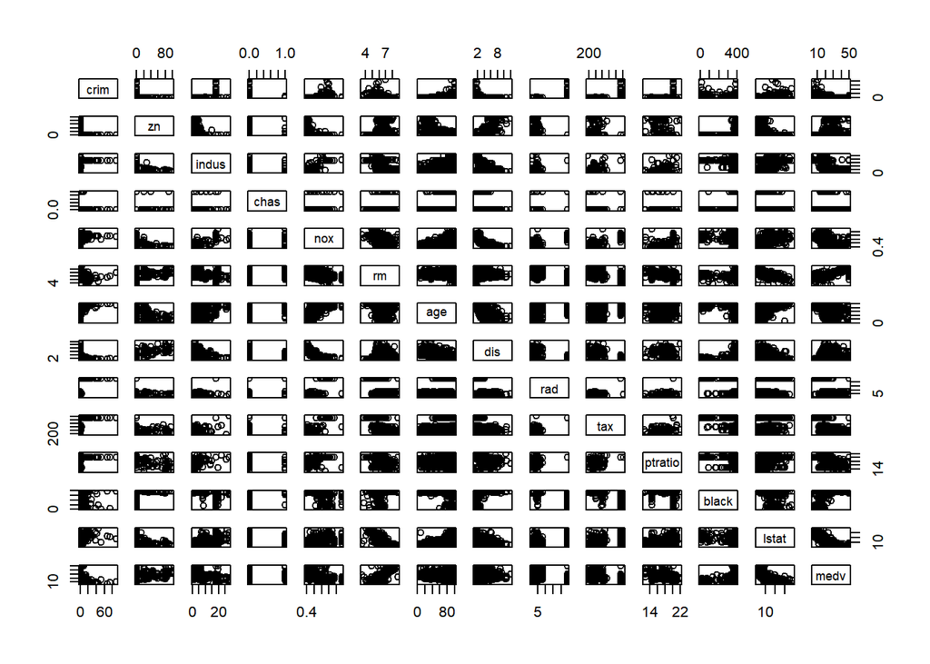

```r
library(corrplot)
library(tidyverse)
library(dplyr)
library(tidyr)
pairs(Boston)
```

```r
summary(Boston)
```

```
##       crim                zn             indus            chas
##  Min.   : 0.00632   Min.   :  0.00   Min.   : 0.46   Min.   :0.00000
##  1st Qu.: 0.08204   1st Qu.:  0.00   1st Qu.: 5.19   1st Qu.:0.00000
##  Median : 0.25651   Median :  0.00   Median : 9.69   Median :0.00000
##  Mean   : 3.61352   Mean   : 11.36   Mean   :11.14   Mean   :0.06917
##  3rd Qu.: 3.67708   3rd Qu.: 12.50   3rd Qu.:18.10   3rd Qu.:0.00000
##  Max.   :88.97620   Max.   :100.00   Max.   :27.74   Max.   :1.00000
##       nox               rm             age              dis
##  Min.   :0.3850   Min.   :3.561   Min.   :  2.90   Min.   : 1.130
##  1st Qu.:0.4490   1st Qu.:5.886   1st Qu.: 45.02   1st Qu.: 2.100
##  Median :0.5380   Median :6.208   Median : 77.50   Median : 3.207
##  Mean   :0.5547   Mean   :6.285   Mean   : 68.57   Mean   : 3.795
##  3rd Qu.:0.6240   3rd Qu.:6.623   3rd Qu.: 94.08   3rd Qu.: 5.188
##  Max.   :0.8710   Max.   :8.780   Max.   :100.00   Max.   :12.127
##       rad              tax           ptratio          black
##  Min.   : 1.000   Min.   :187.0   Min.   :12.60   Min.   :  0.32
##  1st Qu.: 4.000   1st Qu.:279.0   1st Qu.:17.40   1st Qu.:375.38
##  Median : 5.000   Median :330.0   Median :19.05   Median :391.44
##  Mean   : 9.549   Mean   :408.2   Mean   :18.46   Mean   :356.67
##  3rd Qu.:24.000   3rd Qu.:666.0   3rd Qu.:20.20   3rd Qu.:396.23
##  Max.   :24.000   Max.   :711.0   Max.   :22.00   Max.   :396.90
##      lstat            medv
##  Min.   : 1.73   Min.   : 5.00
##  1st Qu.: 6.95   1st Qu.:17.02
##  Median :11.36   Median :21.20
##  Mean   :12.65   Mean   :22.53
##  3rd Qu.:16.95   3rd Qu.:25.00
##  Max.   :37.97   Max.   :50.00
```

The correlation matrix shown here are in the form of a heat-map. Dark red color meaning negatively correlated, dark blue color meaning positively correlated, and white meaning no correlation. You can easily spot certain pairs that have stronger correlations from the graph.

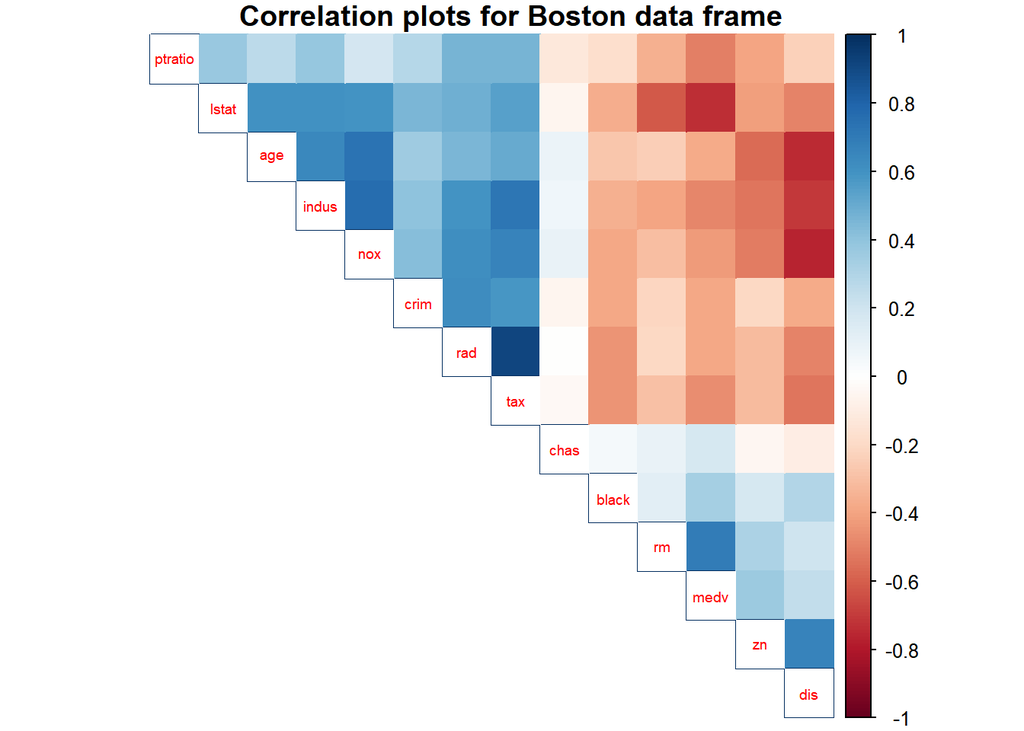

```r
cor_matrix <- cor(Boston)
corrplot(cor_matrix, method="color", order="hclust", type = "upper", cl.pos = "r", tl.pos = "d", tl.cex = 0.6, title = "Correlation plots for Boston data frame", mar=c(0,0,1,0))
```

> **Step 2.** Scaling and preparing the data for categorising.

The `Boston` data is standardised and its summary printed here. Scaling of data may be useful and/or necessary under certain circumstances (e.g. when variables span different ranges). Standardization is the scaling procedure which results in a zero mean and unit variance of any descriptor variable. For every data value the mean μ has to be subtracted, and the result has to be divided by the standard deviation σ (note that the order of these two operations must not be reversed):

```r
boston_scaled <- scale(Boston)
summary(boston_scaled)
```

```
##       crim                 zn               indus
##  Min.   :-0.419367   Min.   :-0.48724   Min.   :-1.5563
##  1st Qu.:-0.410563   1st Qu.:-0.48724   1st Qu.:-0.8668
##  Median :-0.390280   Median :-0.48724   Median :-0.2109
##  Mean   : 0.000000   Mean   : 0.00000   Mean   : 0.0000
##  3rd Qu.: 0.007389   3rd Qu.: 0.04872   3rd Qu.: 1.0150
##  Max.   : 9.924110   Max.   : 3.80047   Max.   : 2.4202
##       chas              nox                rm               age
##  Min.   :-0.2723   Min.   :-1.4644   Min.   :-3.8764   Min.   :-2.3331
##  1st Qu.:-0.2723   1st Qu.:-0.9121   1st Qu.:-0.5681   1st Qu.:-0.8366
##  Median :-0.2723   Median :-0.1441   Median :-0.1084   Median : 0.3171
##  Mean   : 0.0000   Mean   : 0.0000   Mean   : 0.0000   Mean   : 0.0000
##  3rd Qu.:-0.2723   3rd Qu.: 0.5981   3rd Qu.: 0.4823   3rd Qu.: 0.9059
##  Max.   : 3.6648   Max.   : 2.7296   Max.   : 3.5515   Max.   : 1.1164
##       dis               rad               tax             ptratio
##  Min.   :-1.2658   Min.   :-0.9819   Min.   :-1.3127   Min.   :-2.7047
##  1st Qu.:-0.8049   1st Qu.:-0.6373   1st Qu.:-0.7668   1st Qu.:-0.4876
##  Median :-0.2790   Median :-0.5225   Median :-0.4642   Median : 0.2746
##  Mean   : 0.0000   Mean   : 0.0000   Mean   : 0.0000   Mean   : 0.0000
##  3rd Qu.: 0.6617   3rd Qu.: 1.6596   3rd Qu.: 1.5294   3rd Qu.: 0.8058
##  Max.   : 3.9566   Max.   : 1.6596   Max.   : 1.7964   Max.   : 1.6372
##      black             lstat              medv
##  Min.   :-3.9033   Min.   :-1.5296   Min.   :-1.9063
##  1st Qu.: 0.2049   1st Qu.:-0.7986   1st Qu.:-0.5989
##  Median : 0.3808   Median :-0.1811   Median :-0.1449
##  Mean   : 0.0000   Mean   : 0.0000   Mean   : 0.0000
##  3rd Qu.: 0.4332   3rd Qu.: 0.6024   3rd Qu.: 0.2683
##  Max.   : 0.4406   Max.   : 3.5453   Max.   : 2.9865
```

```r
boston_scaled <- as.data.frame(boston_scaled)
```

A categorical variable of the crime rate is created in the Boston dataset (from the scaled crime rate). The quantiles are used as the break points in the categorical variable. The old crime rate variable from the dataset is deleted.

```r
bins <- quantile(boston_scaled$crim)
crime <- cut(boston_scaled$crim, breaks = bins, include.lowest = TRUE, labels = c("low", "med_low", "med_high", "high"))
boston_scaled <- dplyr::select(boston_scaled, -crim)
boston_scaled <- data.frame(boston_scaled, crime)
```

Divide the dataset to train and test sets, so that 80% of the data belongs to the train set.

```r
n <- nrow(boston_scaled)
ind <- sample(n,  size = n * 0.8)
train <- boston_scaled[ind,]
test <- boston_scaled[-ind,]
correct_classes <- test$crime
test <- dplyr::select(test, -crime)
```

> **Step 3.** Linear discriminant analysis (LDA).

Linear Discriminant analysis is a classification (and dimension reduction) method. It finds the (linear) combination of the variables that separate the target variable classes. Here we fit the `crime` variable by all other variables available in the dataset as predictors.

```r
lda.fit <- lda(crime ~ ., data = train)
lda.fit
```

```
## Call:
## lda(crime ~ ., data = train)
##
## Prior probabilities of groups:
##       low   med_low  med_high      high
## 0.2301980 0.2524752 0.2475248 0.2698020
##
## Group means:
##                  zn      indus        chas        nox          rm
## low       0.8931270 -0.8682747 -0.10299142 -0.8428280  0.43479532
## med_low  -0.1042885 -0.2434155 -0.04073494 -0.5540745 -0.15219997
## med_high -0.3568937  0.1566714  0.12138096  0.4371415  0.09012819
## high     -0.4872402  1.0169738 -0.01948777  1.0563368 -0.40437474
##                 age        dis        rad        tax     ptratio
## low      -0.8294481  0.8229534 -0.6830228 -0.7619684 -0.37928206
## med_low  -0.3238524  0.3589574 -0.5551369 -0.4617700 -0.04602945
## med_high  0.4391687 -0.3760089 -0.4041923 -0.3117839 -0.34159455
## high      0.8218221 -0.8529205  1.6395837  1.5150965  0.78247128
##                black       lstat         medv
## low       0.38569048 -0.76589451  0.521376144
## med_low   0.30822007 -0.08719587 -0.006338573
## med_high  0.08549406  0.03443980  0.142348468
## high     -0.80066196  0.85984969 -0.670410358
##
## Coefficients of linear discriminants:
##                 LD1          LD2         LD3
## zn       0.09450994  0.711089888 -0.99028467
## indus    0.02518457 -0.061547149  0.32138626
## chas    -0.09651509  0.014951073  0.10921491
## nox      0.39637891 -0.893329820 -1.21999783
## rm      -0.08578430 -0.117595509 -0.13381147
## age      0.25160651 -0.326022554 -0.14452509
## dis     -0.06536759 -0.267841825  0.33067526
## rad      3.25161509  0.957763631 -0.35931505
## tax     -0.07265144 -0.073141773  0.81952002
## ptratio  0.15120536 -0.003421438 -0.25178136
## black   -0.12051458  0.045986716  0.09804283
## lstat    0.19994892 -0.269330247  0.54106174
## medv     0.20467794 -0.452620296  0.02651721
##
## Proportion of trace:
##    LD1    LD2    LD3
## 0.9525 0.0338 0.0137
```

The data is divided into four colours based on the `crime` category and the plot below shows the LDA results of them.

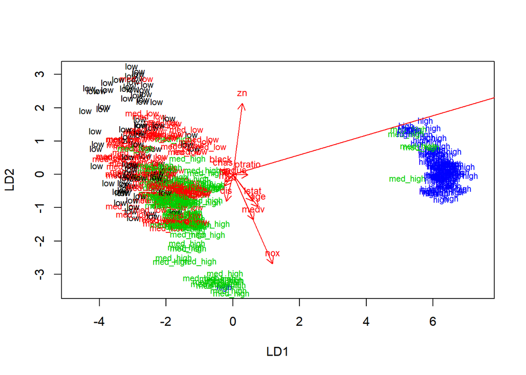

```r
lda.arrows <- function(x, myscale = 1, arrow_heads = 0.1, color = "red", tex = 0.75, choices = c(1,2)){
  heads <- coef(x)
  arrows(x0 = 0, y0 = 0,
         x1 = myscale * heads[,choices[1]],
         y1 = myscale * heads[,choices[2]], col=color, length = arrow_heads)
  text(myscale * heads[,choices], labels = row.names(heads),
       cex = tex, col=color, pos=3)
}
classes <- as.numeric(train$crime)
plot(lda.fit, dimen = 2, col = classes, pch = classes)
lda.arrows(lda.fit, myscale = 3)
```

> **Step 4.** Prediction by LDA.

The prediction of the classes with the LDA model on the test data was conducted.

```r
lda.pred <- predict(lda.fit, newdata = test)
```

Cross tabulate the results with the crime categories from the test set. It seems that most of the predictions are indeed correct.

```r
table(correct = correct_classes, predicted = lda.pred$class) %>% addmargins
```

```
##           predicted
## correct    low med_low med_high high Sum
##   low       23       9        2    0  34
##   med_low    6      15        3    0  24
##   med_high   0      10       15    1  26
##   high       0       0        0   18  18
##   Sum       29      34       20   19 102
```

The total proportion of inaccurately predicted individuals is computed here:

```r
table(correct = correct_classes, predicted = lda.pred$class) %>% prop.table() %>% addmargins()
```

```
##           predicted
## correct            low     med_low    med_high        high         Sum
##   low      0.225490196 0.088235294 0.019607843 0.000000000 0.333333333
##   med_low  0.058823529 0.147058824 0.029411765 0.000000000 0.235294118
##   med_high 0.000000000 0.098039216 0.147058824 0.009803922 0.254901961
##   high     0.000000000 0.000000000 0.000000000 0.176470588 0.176470588
##   Sum      0.284313725 0.333333333 0.196078431 0.186274510 1.000000000
```

```r
loss_func <- function(class, prob) {
  n_wrong <- class != prob
  mean(n_wrong)
}
loss_func(class = correct_classes, prob = lda.pred$class)
```

```
## [1] 0.3039216
```

> **Step 5.** Distance measures.

Similarity or dissimilarity of objects can be measured with distance measures. There are many different measures for different types of data. The most common or “normal” distance measure is Euclidean distance.

Here, we reload and standardsize the `Boston` dataset.

```r
library(MASS)
data('Boston')
boston_scaled <- scale(Boston)
```

The distances between the observations are calculated:

1. Euclidean distance

```r
dist_eu <- dist(boston_scaled)
summary(dist_eu)
```

```
##    Min. 1st Qu.  Median    Mean 3rd Qu.    Max.
##  0.1343  3.4625  4.8241  4.9111  6.1863 14.3970
```

2. Manhattan distance

```r
dist_man <- dist(boston_scaled, method = "manhattan")
summary(dist_man)
```

```
##    Min. 1st Qu.  Median    Mean 3rd Qu.    Max.
##  0.2662  8.4832 12.6090 13.5488 17.7568 48.8618
```

To find the optimal K-means value, the total of within cluster sum of squares (WCSS) vs. the number of cluster changes is plotted.

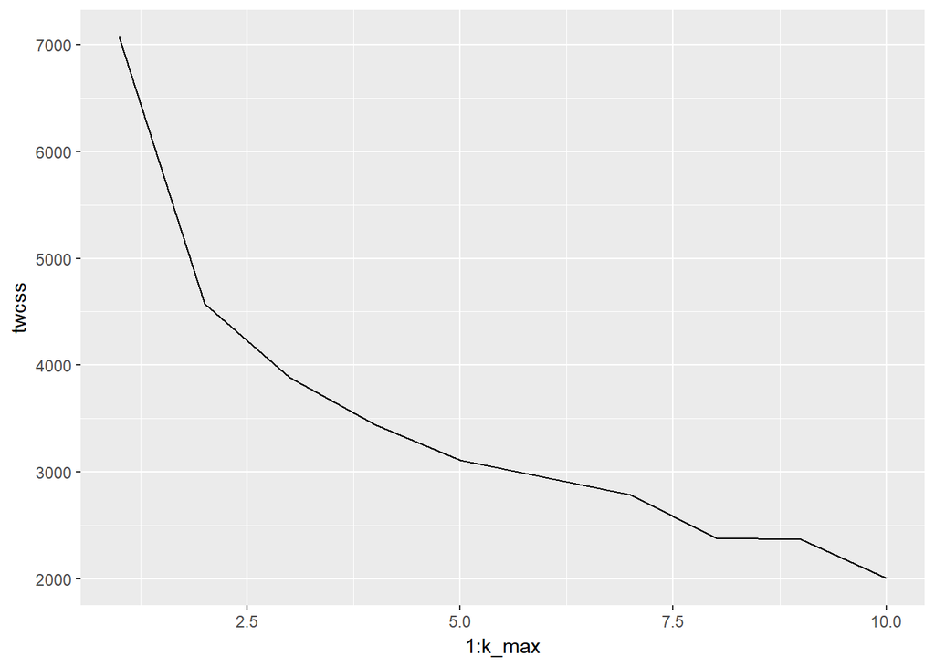

```r
library(ggplot2)
set.seed(123)
k_max <- 10
twcss <- sapply(1:k_max, function(k){kmeans(boston_scaled, k)$tot.withinss})
qplot(x = 1:k_max, y = twcss, geom = 'line')
```

The optimal number of clusters is when the total WCSS drops radically. In this case, the optimal K-means values is 2. The clusters are then visualised here:

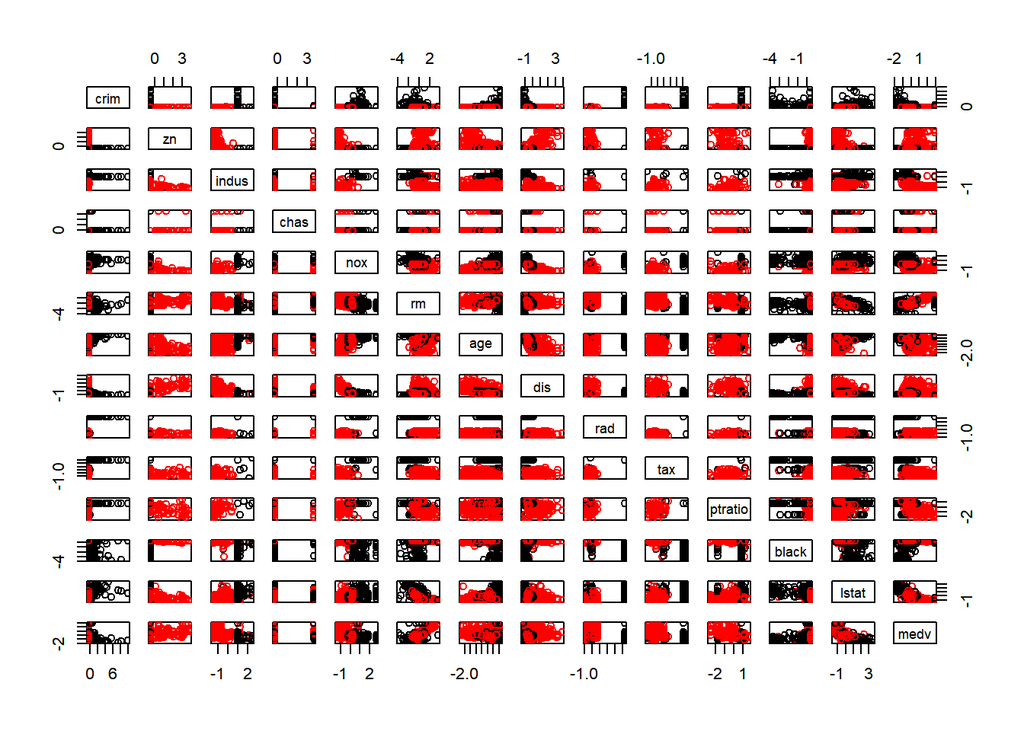

```r
km <-kmeans(boston_scaled, centers = 2)
pairs(boston_scaled, col = km$cluster)
```

The data in the standardised Boston dataset are classified into two clusters based on the K-means analysis. From the graph you can see that the data from the same cluster seem to be continurous and forms a lump in all distributions. However, we cannot simply say that the two clusters is the best fit for the current data. More realistic questions need to be taken into consideration when deciding the number of the clusters.

> **Concluding remarks.**

In the current chapter, we explored the clustering and classification of the data. LDA was used for fitting and predicting the variable based on the training data and gave a relatively good predicting power. The data are clustered by K-means analysis and the opitmal K-means values are explored.